# Fragilidad bancaria, riesgo de cola del crecimiento y spread soberano

# 8 Sección 5 — Síntesis: triangulación de $\theta$ (JLoss × GaR)

```r
get_theta <- function(m, label) {
  ct <- coeftest(m, vcov = DK(m))
  data.frame(modelo = label,
             theta = ct["JxG_c","Estimate"],
             se = ct["JxG_c","Std. Error"],
             p = ct["JxG_c","Pr(>|t|)"])
}

synth <- bind_rows(
  get_theta(mods_corta$M2, "1. LatAm corta — M2 (FE2)"),
  get_theta(mods_corta$M3, "1. LatAm corta — M3 (+controles)"),
  get_theta(M_dom_corta,   "1. LatAm corta — X_dom_idx (FE2)"),
  get_theta(M_glob_corta,  "1. LatAm corta — X_global_idx (FE país)"),
  get_theta(mods_larga$M2, "2. LatAm larga — M2 (FE2)"),
  get_theta(mods_larga$M3, "2. LatAm larga — M3 (+controles)"),
  get_theta(M_dom_larga,   "2. LatAm larga — X_dom_idx (FE2)"),
  get_theta(M_glob_larga,  "2. LatAm larga — X_global_idx (FE país)"),
  get_theta(M_ext_pais,    "3. Extendido — muestra completa, FE país"),
  get_theta(M_glob_ext,    "3. Extendido — X_global_idx (FE país)"),
  get_theta(M_win_2w,      "3. Extendido — ventana común, FE2"),
  get_theta(M_latamwin_2w, "3b. Solo LatAm-5 — ventana común, FE2")
) %>%
  mutate(lo = theta - 1.96*se, hi = theta + 1.96*se)

kable(synth %>% mutate(across(c(theta, se, p), ~round(., 4))),
      caption = "Coeficiente θ de JLoss × GaR a través de las tres bases") %>%
  kable_styling(full_width = FALSE)
```

Coeficiente θ de JLoss × GaR a través de las tres bases

modelo

theta

se

p

lo

hi

1. LatAm corta — M2 (FE2)

-0.3522

0.0887

0.0001

-0.5260506

-0.1783648

1. LatAm corta — M3 (+controles)

-0.3156

0.1020

0.0024

-0.5155510

-0.1155653

1. LatAm corta — X_dom_idx (FE2)

-0.3058

0.0932

0.0013

-0.4885159

-0.1231002

1. LatAm corta — X_global_idx (FE país)

-0.3576

0.1334

0.0078

-0.6189916

-0.0962104

2. LatAm larga — M2 (FE2)

-0.3361

0.1197

0.0054

-0.5706780

-0.1014983

2. LatAm larga — M3 (+controles)

-0.3053

0.1380

0.0282

-0.5757873

-0.0347179

2. LatAm larga — X_dom_idx (FE2)

-0.3272

0.1141

0.0046

-0.5507814

-0.1035247

2. LatAm larga — X_global_idx (FE país)

-0.3909

0.1689

0.0214

-0.7218664

-0.0598710

3. Extendido — muestra completa, FE país

-0.1816

0.1832

0.3224

-0.5407123

0.1775694

3. Extendido — X_global_idx (FE país)

-0.1567

0.1742

0.3688

-0.4981352

0.1846721

3. Extendido — ventana común, FE2

0.6257

0.2943

0.0350

0.0489371

1.2024539

3b. Solo LatAm-5 — ventana común, FE2

-0.0739

0.1264

0.5605

-0.3216385

0.1738289

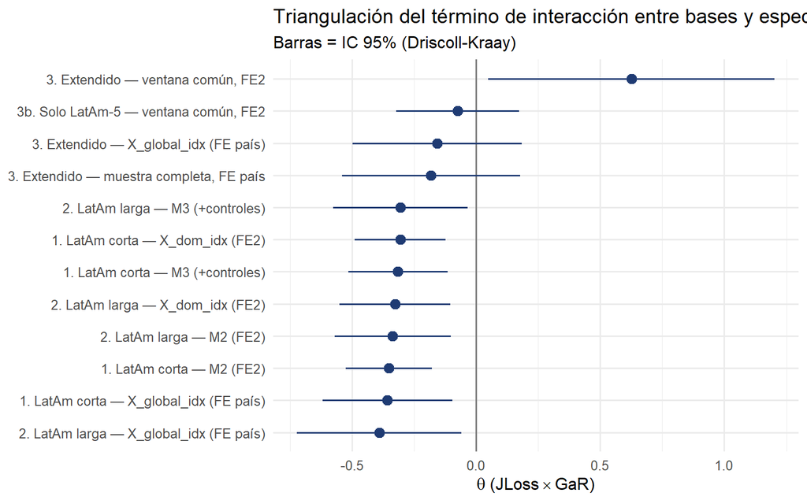

```r
ggplot(synth, aes(x = theta, y = reorder(modelo, theta))) +
  geom_vline(xintercept = 0, color = "grey50") +
  geom_pointrange(aes(xmin = lo, xmax = hi), color = "#1f3b73") +
  labs(x = expression(theta ~ "(JLoss" %*% "GaR)"), y = NULL,
       title = "Triangulación del término de interacción entre bases y especificaciones",
       subtitle = "Barras = IC 95% (Driscoll-Kraay)") +
  theme_minimal(base_size = 12)
```

*Estimación: `plm` (agrupado y efectos fijos* within*). Inferencia: Driscoll-Kraay (`vcovSCC`) salvo donde se compara explícitamente con otros estimadores de varianza. Fuentes: EMBI real BCRP (LatAm) + tablas GFSR del FMI 2011-2015 (extendido); GaR de `gar_panel_all15.csv`; JLoss de `Jloss.dta`; controles domésticos y VIX/g_GDP solo disponibles para el núcleo LatAm; VIX global CBOE disponible para las tres bases.*